# Nat4Wat Reference manual

Author

Josep Pueyo-Ros

**Note**

This document is work in progress. Content will evolve as the tool evolves.

# 1 Knowledge base

## 1.1 Technologies

Table 1 shows all available technologies and Table 2 all the information included in the table. Technologies were collected using expert-based knowledge as explained [here](https://iwaponline.com/bgs/article/5/2/235/99349/Development-of-a-decision-support-system-to-select?searchresult=1) and [here](https://zenodo.org/records/10688075).

The available technologies can be consulted in the tool or can be downloaded as csv or [json](https://nat4wat-api.icradev.cat/technologies/technologies).

Table 1: Technologies included in Nat4Wat

| Technology | Type | Function |
| --- | --- | --- |
| Aerated treatment wetland | CW | Water treatment |
| Aerated treatment wetland for CSO | CW | Water treatment |
| Free water surface treatment wetland | CW | Water treatment |
| French vertical flow treatment wetland | CW | Water treatment |
| Horizontal flow treatment wetland | CW | Water treatment |
| Phytoparking | CW | Water treatment |
| Rain garden with treatment | CW | Water treatment |
| Reactive media in treatment wetland | CW | Water treatment |
| Reciprocating treatment wetland | CW | Water treatment |
| Rhizosph'air aerated french wetland | CW | Water treatment |

[output cut: 44 more lines]

Table 2: Information provided by experts for each technology

| Variable | Description | Values or units |
| --- | --- | --- |
| name | The name of the technology | -- |
| type | The group of the technology | BS: Bioretention systems<br> CW: Constructed wetlands<br> DB: Detention basins<br> FS: Filter strips<br> GR: Green roofs<br> GW: Green walls<br> HA: Hydroponics and Aquaponics<br> IS: Infiltration sys… |
| description | A brief description of the technology | -- |
| vertical | Is the technology a vertical structure (i.e., a green wall)? | 0 (no)<br> 1 (yes) |
| lost_flowrate | The proportion of flowrate that is lost due to evapotranspiration | -- |
| bod_removal | Performace removal for biological organic matter | % |
| cod_removal | Performace removal for chemical organic matter | % |
| nh4_removal | Performace removal for ammonia | % |
| tn_removal | Performace removal for total nitrogen | % |
| no3_removal | Is the technology actively doing denitrification (removing nitrates and nitrites)? | 0 (no)<br> 1 (yes) |

[output cut: 51 more lines]

**NoteAknowledgement**

The illustrations of the technologies showed in Nat4Wat were made by Lide Jaurrieta.

## 1.2 Scientific publications

Scientific publications are the result of several systematic scientific reviews, as explained in Acuña et al. (2023) and in [Deliverable 4.2](https://zenodo.org/records/10688075) of the MULTISOURCE project. User can upload new scientific publications that are published after a peer-review process. This data, especially for water treatment, is used by machine learning models to estimate the surface based on inflow and concentration in the inlet and outlet.

## 1.3 Market cases

Market cases are provided by companies with expertise in building the technologies avaiable in the tool. To upload a market case, a company needs to register as a company and upload the required information. The market cases are published after a peer-review process.

## 1.4 Water inputs and transformations

The water types is the primary selector of technologies. In the knowledge base, each technology is assigned to one or several types of water. In treatment scenarios, if any more data is provided, the BOD concentration and the inflow as estimated from the type of water according to the values in Table 3.

Table 3: Water types accepted as input

|  | people equivalent | gr BOD/day | litres/person/day |
| --- | --- | --- | --- |
| Water treatment scenario |  |  |  |
| Any wastewater | 1.00 | 60 | 120 |
| Raw domestic wastewater | 1.00 | 60 | 120 |
| Greywater | 0.33 | 20 | 100 |
| Secondary treated wastewater | 0.05 | 3 | 120 |
| Pretreated domestic wastewater | 0.80 | 48 | 120 |
| River diluted wastewater | 0.05 | 3 | 120 |
| Camping wastewater | 0.80 | 48 | 120 |
| Offices wastewater | 0.50 | 30 | 120 |
| NA |  |  |  |
| CSO discharge water | 0.50 | 30 |  |
| Storm water management scenario |  |  |  |
| Rain water | 0.00 | 0 |  |
| Runoff water | 0.05 | 3 |  |

# 2 Selection of technologies

The selection of technologies is based on the information provided by experts (Table 1 and Table 2). The inputs from the user are matched with the information of each technology and technologies not fulfilling one of the conditions are rejected.

- If “Any wastewater” is selected, technologies for stormwater management are rejected, but all technologies for water treatment are selected, regardless of the type of wastewater they can handle.
- If “Vertical” is selected, vertical technologies such as green walls are selected. This option does not reject horizontal technologies.
- If “household building solutions” is selected, all technologies designed for larger scales are rejected. However, if this is not selected, no technology is rejected.
- When some input values for an ecosystem service are provided, all technologies with a smaller score in that ecosystem service are rejected, but not the ones with larger scores. For instance, if a user selects level 2 in temperature regulation, only technologies with scores 2 or 3 in temperature regulation are selected.
- On the other hand, when an input value is provided for an operational constraint (required manpower, required skills or biohazard risks), technologies with larger scores are rejected. For instance, if a user selects level 2 in required skills, only technologies with scores 0, 1 or 2 in required skills are selected.
- If energy requirements are selected as yes, all technologies that need electrical energy to work are selected. On the other hand, if energy requirements are selected as no, all technologies that need electrical energy to work are rejected.
- In case of NBS for water treatment, the technologies can be filtered according the pollutants they can remove. In that case, BOD, COD, TN and NH<sub>4</sub> have information about removal percentages while NO<sub>3</sub>, P and pathogens are presented as binary variables (active - inactive).
  - BOD, COD, TN, NH<sub>4</sub>: If these pollutants are selected, all technologies with a removal percentage lower than 80% are rejected. However, if the user enter input and output (or target) concentrations, then the required removal percentage is calculated and the technologies are filtered accordingly. For instance, an aerated treatment wetlands has a removal of TN of 60%. Therefore, if the user only selects TN in the list of pollutants of interest, aerated treatment wetlands are rejected. However, if the user, apart from selecting TN, also enters an input concentration of 20 mg/L and a required concentration in the output of 10 mg/L, aerated treatment wetlands are selected because the required removal percentage is 50% ($(20 - 10)/20$) and aerated treatment wetlands can satisfy this requirement.
  - NO<sub>3</sub>, P and pathogens: If these pollutants are selected, the technologies that are inactive for the selected pollutants are rejected.

# 3 Surface estimation

## 3.1 Treatment surface

The method to estimate the surface of a technology for water treatment depends on two factors (Figure 1):

- The information provided by the user about the water requirements.
- The information available in the tool regarding the technology.

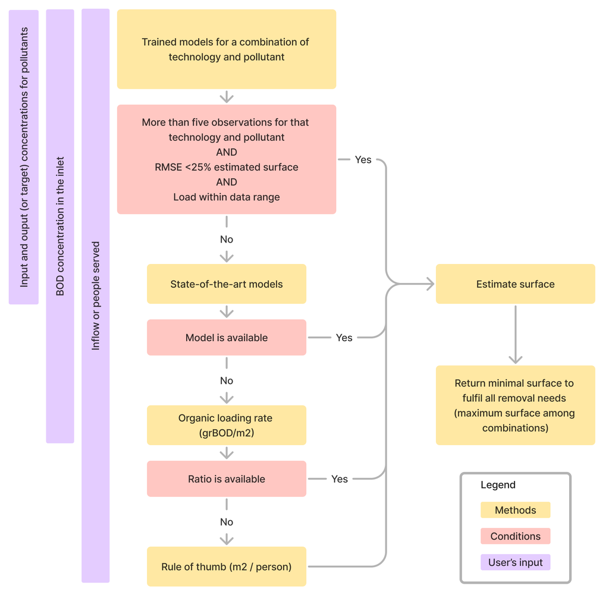

Figure 1: Cascade model diagram

If input and output concentrations are provided for more than one pollutant, the surface returned is the minimal surface to fulfil all removal requirements (i.e. the maximum surface among pollutants used in the estimation).

### 3.1.1 Data-driven models

Three different regression models were fitted for each combination of technology and pollutant provided that there were more than five observations for that combination. The three regression models were linear, exponential and power, from the original models, we isolated surface to facilitate future operations with the models:

- Linear model: $L_o = L_i - \beta{S}$ ► $S = \beta (L_i-L_o)$
- Exponential model: $L_o = L_i e^{-\beta S}$ ► $S = \beta ln(\frac{L_i}{L_o})$
- Power model: $L_o = L_i - aS^\beta$ ► $log_{10}(S) = \alpha + \beta log_{10}(L_i - L_o)$

Note that linear and exponential models are without intercept (zero removal = zero surface), while power model has an intercept. Because of this, $\beta$ in the power model can adopt negative values, which are not mechanistically feasible. Therefore, power models with negative values of $\beta$ were discarded.

Once, the three models were fitted, we calculated the RMAE (Relative Median Absolute Error) is calculated for each model, we used the meadian instead of the mean to make the errors more robust to outliers, since the distribution of the values is not normally distributed. Likewise, we used relative errors instead of absolute to use more sensible errors. We considered that from the point of view of the end users, a percentual error is more meaningful. For instance, an absolute error of 2m<sup>2</sup> is an error of 50% in a NBS of 4m<sup>2</sup> but an error of 5% in a NBS of 40m<sup>2</sup>.

Then, we chose the model with the lowest RMAE. If the RMAE was lower than 25%, the model was marked as suitable for predicting the surface of new technologies. However, this model is only used when the input from the user is within the range that was used to fit the model, with a tolerance of 25%. For instance, if the BOD loads found in the for a horizontal flow green wall were between 10 and 30 gr of BOD per day, if the loads entered by the user were lower than 7.5 or greater than 37.5, the model is not used and the surface is estimated using the next step in the cascade, if available.

### 3.1.2 Mechanistic models

If there are no model available, the algorithm searchers for an available mechanistic model for each technology. Available mechanistic models are described below:

#### 3.1.2.1 Tank-in-Series model

A Tank-in-Series model is used for horizontal flow subsurface wetlands and green walls (Kadlec and Wallace 2009). The model calculates the outflow concentrations as a function of several parameters:

$$C_o = C_* + (C_i - C_*)(1 + \frac{kS}{QN})^{-N}$$
Where:

- *C<sub>o</sub>*: Outflow concentration (mg/l).
- *C**: Background concentration (mg/l).
- *C<sub>i</sub>*: Inflow concentration (mg/l).
- *k*: Kinetics ratio (m/year).
- *S*: Treatment surface (m<sup>2</sup>).
- *Q*: Inflow (m<sup>3</sup>/year).
- *N*: Number of beds.

From that, we isolated the surface, which is our unknown parameter:

$$S = [(\frac{C_o - C_*}{C_i - C_*})^{-\frac{1}{N}}-1]Q\frac{N}{k}$$

Kinetics (*k*) and background concentrations (*C**) are defined based on literature values as follows:

- BOD:
  - $C_* = 0.6 + 0.4C_i^{0.55}$
  - For *C<sub>i</sub>* > 200: $k = 66$
  - For *C<sub>i</sub>* > 100: $k = 25$
  - For *C<sub>i</sub>* > 30: $k = 37$
  - For *C<sub>i</sub>* > 3: $k = 86$
- COD:
  - $C_* = 0$
  - $k = 37.6$
- TN:
  - $C_* = 1$
  - $k = 8.4$
- NH<sub>4</sub>:
  - $C_* = 0$
  - $k = 11.4$

The other parameter to define is the number of beds (*N*). *N* is calculated as follows (Sperling, Wallace, and Nivala 2023):

$$N = 0.686(\frac{L}{h})^{0.0671}$$
Where *L* is the length of the bed and *h* is the depth. We use predefined values for *h* of 0.7 for wetlands and 0.2 for green walls. To calculate *L* we use the ratio length:width (*r*) to calculate *L* from the surface:

$$L = \sqrt{Sr}$$
We use a ratio of 2:1 for wetlands and 10:1 for green walls. Yet, *S* remains unknown, it is indeed our parameter of interest. Therefore, to calculate *N* we estimate a prior surface using the rule of thumb method, based on the people equivalent served by the technology (Section 3.1.4).

### 3.1.3 Organic loading rate

The organic loading rate defines the load of organic matter (in grams of BOD/day) that a technology can handle. Based on the expert assessment, we defined a value for each technology and for four different climates based on [Köppen classification](https://www.britannica.com/science/Koppen-climate-classification) (tropical, dry, temperate and continental). The user can also provide the average temperature of the coolest month in their are. In that case the climate is classified as follows:

- average temperature < -3: continental
- average temperature < 18: temperate
- average temperature >= 18: tropical

In terms of the temperature, there are no differences between tropical and dry, as there aren’t in terms of the organic loading rate.

### 3.1.4 Rule of thumb

If the user only entered inflow or people served, or none of the above steps is available, the surface is estimated using the rule of thumb. The rule of thumb is also based in expert assessment as the organic loading rate. It defines the squared meters needed for each person equivalent (p.e.). The person equivalent is calculated based on the people served and the water type. In Table 3 there is a column of equivalencies between people served and people equivalent for each type of water. For instance, 10 people served by a technology receiving greywater is equivalent to 3.3 p.e.

In case the user enters the inflow instead of the people served, the latter is calculated using the litres/person/day of each type of water, also defined in Table 3.

As with the organic loading rate (Section 3.1.3), the rule of thumb is defined for the same four climates, that are classified using the same criteria as above.

### 3.1.5 Target concentrations in the receiving environment

In case that the user request to know target concentrations in the receiving environment (instead of outlet concentrations), a mass balance is used to calculate the downstream concentration. For that, the user must provide river’s upstream inflow and concentrations for each pollutant of interest. We assume that flow in the technology is constant from the inlet to the outlet. The target (or downstream) concentration is calculated as follows:

$$C_t = \frac{C_uQ_u + C_oQ_i}{Q_u + Q_i}$$

where:

- C<sub>t</sub>: Target concentration required in the downstream river
- C<sub>u</sub>: Upstream river concentration
- C<sub>o</sub>: Required concentration in the outlet
- Q<sub>u</sub>: Upstream river flow
- Q<sub>i</sub>: Technology inflow

## 3.2 Retention - infiltration surface

The volume that the technology can manage can be calculated with the following equation:

$$V = A · (\phi K_tt_1 + K_st_2) + Q_dt_2$$

$$if ~ K_tt <= H, ~ then ~ t_1 = t ~ and ~ t_2 = 0$$

$$otherwise, ~ t_1 = \frac{H}{K_t} ~ and ~ t_2 = t - t_1$$

where:

- *V*: Volume at the time *t* that the technology can retain or infiltrate (m<sup>3</sup>).
- *A*: surface of the technology (m<sup>2</sup>)
- *K<sub>t</sub>*: Hydraulic conductivity of the technology’s layers (m/s). When the technology stores water in a superficial layer, this is assumed as 10 m/s.
- *K<sub>s</sub>*: Hydraulic conductivity of the receiving soil (m/s).
- *t*: duration of the rain event (s)
- $\phi$: storage capacity of the technology (m<sup>3</sup>/m<sup>3</sup>)
- *H*: height of the technology (m).
- *Q<sub>d</sub>*: The flow of the drainage pipe (m<sup>3</sup>/s).
- *t<sub>1</sub>*: Time spent for water to arrive to the bottom of the technology (i.e. time to be filled).
- *t<sub>2</sub>*: Time since the technology was filled by water.

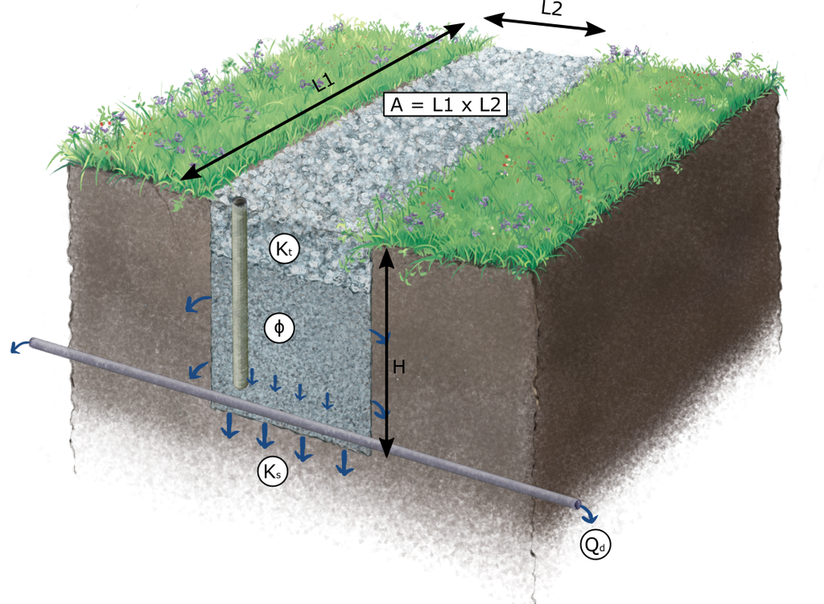

Figure 2: Schema for an infiltration trench

The method assumes that the critical time of the event (when the maximum retention volume is needed) is at the end of the event.

From the previous equation, the surface can be estimated as follows:

$$A = \frac{V - Q_dt'_1}{\phi K_tt'_0 + K_st'_1}$$

$$if ~ K_tt <= H, ~ then ~ t_1 = t ~ and ~ t_2 = 0$$

$$otherwise, ~ t_1 = \frac{H}{K_t} ~ and ~ t_2 = t - t_1$$

*V* can be approximated as follows:

$$V = \frac{r_{cum(t)}A_c}{1000}$$

where:

- *r<sub>cum(t)</sub>*: Cummulated rain at time *t* (mm).
- *A<sub>c</sub>*: Area of the catchment area of the technology (in m<sup>2</sup>).

*Q<sub>d</sub>* can be calculated as *Q<sub>d</sub> = AV*, where *V* can be replaced by the Manning equation as follows:

$$Q_d = A\frac{1}{n}(\frac{A}{P})^{\frac{2}{3}}S^{\frac{1}{2}}$$

where:

- *A*: Section of the pipe (m<sup>2</sup>)
- *n*: Roughness coefficient for the pipe’s material(default: 0.0011)
- *P*: Perimeter of the pipe (m).
- *S*: slope of the pipe (default: 3%).

The user can provide the diameter of the pipe. If not provided, it is assumed that there is not drainage pipe.

The output of the method contains the surface needed to retain or infiltrate the volume reported and the daily volume that can be retained or infiltrated by the technology with the high interval of the surface.

When the user also provides the available area, the surface estimated is to manage all the volume reported, regardless of the available area. However, the `max_volume` reports the maximum volume that can be retained or infiltrated by the technology using the available area. If the surface needed is lower than the available area, the `max_volume` always equal to the volume reported by the user (= `cumRain` x `catchmentArea` x 0.001). A flag named `enough_area` indicates when the available area is larger than the surface needed to manage the reported flow.

## 3.3 Surface for combined sewer overflow treatment

The criteria to estimate the surface of a CSO treatment solutions is based on two parameters: first flush capture and total spilled volume per year.

### 3.3.1 First flush capture

The first flush capture is the volume of the first *n* mm of water (usually 5 mm). This volume is calculated based on the catchment area:

$$V_{f} = A_c * \frac{H_f}{1000}$$
Where:

- *V<sub>f</sub>*: volume of the first flush in m<sup>3</sup>.
- *A<sub>c</sub>*: Surface of the catchment area feeding the CSO in m<sup>2</sup>.
- *H<sub>f</sub>*: Quantity of the first flush to be captured in mm.

Once, *V<sub>f</sub>* is estimated, the surface of the technology is calculated to absorb this volume:

$$S = \frac{V_f}{H}$$

Where:

- *S*: surface of the technology in m<sup>2</sup>.
- *H*: height of the technology in m.

### 3.3.2 Total spilled volume per year

The total spilled volume per year is the volume of water that is spilled by the CSO in a year. Using this parameter, the surface of the technology can be calculated using the hydraulic loading ratio:

$$S = \frac{V_s}{HLR}$$

Where:

- *S*: Surface of the technology in m<sup>2</sup>.
- *V<sub>s</sub>*: Volume spilled per year in m<sup>3</sup>year<sup>-1</sup>.
- *HLR*: Hydraulic loading rate in m<sup>3</sup>m<sup>-2</sup>year<sup>-1</sup>.

In case, the technology has no information regarding the hydraulic loading rate, this can be approximated using the organic loading rate:

$$HLR = \frac{OLR * 365}{C_{bod} * 1000}$$

Where:

- *HLR*: Hydraulic loading rate in m<sup>3</sup>m<sup>-2</sup>year<sup>-1</sup>.
- *OLR*: Organic loading rate in l·m<sup>2</sup>day<sup>-1</sup>.
- *C<sub>bod</sub>*: Concentration of BOD in g·l<sup>-1</sup> (assumed as 0.25 g·l<sup>-1</sup>).

# 4 Multicriteria decision analysis

Multicriteria decision analysis (MCDA) is a method to weight different criteria to get a final score for each technology. Each criteria is weighted between 0 and 5 regarding the importance that the criteria has in the use case.

## 4.1 Criteria

### 4.1.1 Environmental criteria

#### 4.1.1.1 Environmental impact

It is calculated as a combination of energy use, eutrophication risks due to ammonium, nitrates and phosphates, and climate change mitigation due to carbon sequestration:

$$EI = \frac{(1 - e) + 2r_{NH_4} + r_{NO_3} + r_{PO_4^3} + \frac{cs + r_{CSO}}{3}}{7}$$

Where $EI$ is environmental impact ($\in[0,1]$) being 1 the lowest impact; $e$ is energy use ($\in\{0,1\}$); $r_{NH_4}$ is the capacity of the technology to remove ammonia ($\in[0,1]$); $r_{NO_3}$ is the capacity of the technology to remove nitrates ($\in\{0,1\}$); $r_{PO_4^3}$ is the capacity of the technology to remove phosphates ($\in\{0,1\}$);and $cs$ and $r_{CSO}$ are carbon sequestration capacity of the solution and CSO mitigation potential (both $\in[0,3]$).

#### 4.1.1.2 Biodiversity

Biodiversity considers the capacity of the solution to sustain and enhance biodiversity. It is calculated as a combination of the scores in biodiversity related to flora, to fauna and the capacity to sustain pollinators:

$$B = \frac{flora + fauna + pollinators}{9}$$
Where $B$ is biodiversity enhancement ($\in[0,1]$), being 1 the major biodiversity;$flora$, $fauna$, and $pollinators$ are qualitative scores given to each solution ($\in[0,3]$)

#### 4.1.1.3 Space requirements

Space requirements is the surface needed for the technology. In case, the scenario has enough information to estimate the surface, the estimated mean surface is used. Otherwise, the ratio $m2/pe$ for each technology is used instead. The surfaces of compared technologies are normalized as follows:

$$SR_i = \frac{s_{min}}{s_i}$$

where $SR_i$ is the space requirements ($\in(0,1]$) for technology $i$; $s_{min}$ is the minimum surface among all compared technologies and $s_i$ is the surface of technology $i$. when the data to estimate the surface is not provided, the ratio of $m^2/pe$ is used for treatment technologies (larger ratio equals to smaller score) and $\phi * H$ is used for stormwater management technologies. See Section 3 for more details about surface estimation.

### 4.1.2 Socioeconomic criteria

#### 4.1.2.1 Social benefits

Social benefits are the benefits people obtain from the solution. In this case, we consider aesthetic values, recreational functions (which are diminished in case there is biohazard risks around the solution), and temperature regulation:

$$CB = \frac{av + rf(1 - \frac{br}{3}) + tr + fm}{12}$$

Where $CB$ is cultural benefits ($\in[0,1]$); $av$ is aesthetic value ($\in[0,3]$), $rf$ is the recreational functions ($\in[0,3]$), $tr$ is the temperature regulation ($\in[0,3]$), $fm$ is flood mitigation ($\in[0,3]$) and $br$ is the biohazard risk of being exposed to the solution ($\in[0,3]$).

#### 4.1.2.2 Circularity

Circularity is the capacity of the solution to generate resources that can be used in other processes. Specifically, water reuse and materials are estimated from a combination of different variables:

- Water reuse: lost of flow rate between inlet and outlet, the reduction of pathogens.
- Materials: Expert assessment on biosolids production, biomass production and food production.

$$C = \frac{(1 - lf)(pr + r_{BOD})}{2} + \frac{bsp + bmp + fp}{9}$$

Where $C$ is the circularity score ($\in[0,1]$); $lf$ is the lost of flowrate ($\in[0,1]$); $pr$ is the pathogens reduction capacity ($\in\{0,1\}$); $r_{BOD}$ is the removal performance for BOD ($\in[0,1]$); $bsp$, $bmp$ and $fp$ are the scores assessed by experts in biosolids production, biomass production, and food production, respectively (all of them $\in[0,3]$)

### 4.1.3 Operational criteria

#### 4.1.3.1 Operation and manteinance

Operation and maintenance is the level of difficulty in keep the technology properly working. It is estimated as a combination of required manpower, required skills, biohazard risk of exposition and if energy is required:

$$OM = 1 - \frac{mp + sk + br + 3e}{12}$$

Where $OM$ is the operation and maintenance score ($\in\{0,1\}$) being 1 the lowest operation and manteinance requirements; $mp$ is the level of required manpower ($\in[0,3]$); $sk$ is the level of required skills ($\in[0,3]$); $br$ is the biohazard risk of being exposed to the solution ($\in[0,3]$); and $e$ indicates if energy is required ($\in\{0,1\}$)

#### 4.1.3.2 Construction cost (CAPEX)

The capex is calculated as the total construction capex using the estimated surface. The capexs for all technologies are normalized regarding the technology with the minimal capex.

$$\hat{c}_i = \frac{c_{min}}{c_i}$$
where $\hat{c}_i$ is the normalized construction capex ($\in(0,1]$) for technology $i$; $c_{min}$ is the minimum capex among all compared technologies and $c_i$ is the capex of technology $i$.

#### 4.1.3.3 Removal performance

This criteria compares the solutions in terms of their removal capacity, assumed that all solutions compared already satisfy the scenario requirements in terms of water quality in the effluent:

$$RP = \frac{r_{BOD} + r_{COD} + r_{TN} + r_{NH_4} + r_{NO_3} + r_{PO_4^3} + r_p}{7}$$

Where $RP$ is the score in removal performance ($\in[0,1]$); $r_{BOD}$ is the removal performance in BOD ($\in[0,1]$); $r_{COD}$ is the removal performance in COD ($\in[0,1]$); $r_{TN}$ is the removal performance in total nitrogen ($\in[0,1]$); $r_{NH_4}$ is the removal performance in ammonia ($\in[0,1]$); $r_{NO_3}$ express the capacity to remove nitrates ($\in{0,1}$); $r_{PO_4^3}$ express the capacity to remove phosphates ($\in{0,1}$); and $r_{p}$ express the capacity to reduce pathogens (*E.coli* and H.eggs) ($\in{0,1}$). This criteria is only calculated for wastewater treatment solutions.

The above equation is adapted to the user’s interest regarding the pollutants selected in the scenario. If no pollutants are provided, the equation defaults to BOD, COD and Total Nitrogen.

## 4.2 Weights

Each criteria is weighted by the user according to the priorities of the specific case. Each criteria can be weighted using a 5-point Likert scale from “Not important at all” to “Very important”. Then this information is used to weight the score of each criteria.

Then this weights are converted to proportions ($\Sigma{w} = 1$). Therefore, weighted all criteria as very important get the same results that weighted all of them as not important:

$$p_{wc} = \frac{w_c}{\Sigma{w}}$$
where $p_{wc}$ is the proportion ($\in[0,1]$) of the weight for criteria $c$; $w_c$ is the weight ($\in[0,5]$) for criteria $c$ and $\Sigma{w}$ is the sum of the weights of all criteria.

## References

Acuña, Vicenç, Laura Castañares, Joana Castellar, Joaquim Comas, Katherine Cross, Darja Istenic, Fabio Masi, et al. 2023. “Development of a Decision-Support System to Select Nature-Based Solutions for Domestic Wastewater Treatment.” *Blue-Green Systems* 5 (December): 235–51. https://doi.org/10.2166/BGS.2023.005.

Kadlec, Robert H., and Scott D. Wallace. 2009. *Treatment Wetlands*. 2nd ed. CRCS Press. https://sswm.info/sites/default/files/reference_attachments/KADLEC%20WALLACE%202009%20Treatment%20Wetlands%202nd%20Edition_0.pdf.

Sperling, M. von, S. D. Wallace, and J. Nivala. 2023. “Representing Performance of Horizontal Flow Treatment Wetlands: The Tanks In Series (TIS) and the Plug Flow with Dispersion (PFD) Approaches and Their Application to Design.” *Science of The Total Environment* 859 (February): 160259. https://doi.org/10.1016/j.scitotenv.2022.160259.